# Scraping Twitter for Comcast Email

Jacob Rozran

This document explains my first pass at a sentiment analysis of Twitter to grab those tweets related to Comcast Email.

All of my scripts can be found at [my github page](https://github.com/jrozra200/scraping_twitter)

The first three steps are part of my scraping_twitter.R script.

## Step 1: Get the Tweets

The first thing I did was search Twitter for tweets that had “Comcast Email” in them.

The code I used to do this is:

```r
library(twitteR) ##built in R package that does some of the Twitter API heavy lifting

##Authentication
load("credentials.RData")  ##has my secret keys and shiz
registerTwitterOAuth(twitCred) ##logs me in
```

```
## [1] TRUE
```

```r
##Get the tweets to work with
tweetList <- searchTwitter("comcast email", n = 1000) ##Searches twitter for anything with comcast and email in it

tweetList <- twListToDF(tweetList) ##converts that data we got into a data frame to make it easier to do further analysis
```

As you can see, I used the twitteR R Package to authenticate and search Twitter. After getting the tweets, I converted  
the results to a Data Frame to make it easier to analyze the results.

## Step 2: Get rid of the junk

Many of the tweets returned by my initial search are totally unrelated to Comcast Email. An example of this would be:

“I am selling something random… please **email** me at myemailaddress@**comcast**.net”

The tweet above includes the words email and comcast, but has nothing to actually do with Comcast Email and the way  
the user feels about it, other than they use it for their business.

So… based on some initial, manual, analysis of the tweets, I’ve decided to pull those tweets with the phrases:

- “fix” AND “email” in them (in that order)
- “Comcast” AND “email” in them in that order
- “no email” in them
- Any tweet that comes from a source with “comcast” in the handle
- “Customer Service” AND “email” OR the reverse (“email” AND “Customer Service”) in them

After pulling out the duplicates (some tweets may fall into multiple scenarios from above) and ensuring they are in  
order (as returned initially), I assign the relevant tweets to a new variable with only some of the returned columns.

The returned columns are:

- text
- favorited
- favoriteCount
- replyToSN
- created
- truncated
- replyToSID
- id
- replyToUID
- statusSource
- screenName
- retweetCount
- isRetweet
- retweeted
- longitude
- latitude

All I care about are:

- text
- created
- statusSource
- screenName

```r
fixemail <- grep("(fix.*email)", tweetList$text) ##finds the rows that have the phrase "fix ... email" in them
comcastemail <- grep("[Cc]omcast.*email", tweetList$text) ##finds the rows that have the phrase "comcast ... email" in them
noemail <- grep("no email", tweetList$text) ##finds the rows that have the phrase "no email" in them
comcasttweet <- grep("[Cc]omcast", tweetList$screenName) ##finds the rows that originated from a Comcast twitter handle
custserv <- grep("[Cc]ustomer [Ss]ervice.*email|email.*[Cc]ustomer [Ss]ervice", tweetList$text) ##finds the rows related to email and customer service

##combine all of the "good" tweets row numbers that we greped out above and then sorts them and makes sure they are unique
combined <- c(fixemail, comcastemail, noemail, comcasttweet, custserv)
uvals <- unique(combined)
sorted <- sort(uvals)

##pull the row numbers that we want, and with the columns that are important to us (tweet text, time of tweet, source, and username)
paredTweetList <- tweetList[sorted, c(1, 5, 10, 11)]
```

## Step 3: Clean up the data and return the final list

Lastly, for this first script, I make the sources look nice, add titles, and return the final list (only a sample set  
of tweets shown):

```r
##make the device source look nicer
paredTweetList$statusSource <- sub("<.*\">", "", paredTweetList$statusSource)
paredTweetList$statusSource <- sub("</a>", "", paredTweetList$statusSource)

##name the columns
names(paredTweetList) <- c("Tweet", "Created", "Source", "ScreenName")

head(paredTweetList, n = 10)
```

```
##                                                                                                                                           Tweet
## 2      Dear Mark I am having problems  login into my acct eddygil@comcast.net I get no email w codes to reset my password for eddygil HELP HELP
## 4    @msnbc @nbc @comcast pay @thereval who incites the murder of police officers. Time to send them a message of BOYCOTT! Tweet/email them NOW
## 5  Dear Mark @fnked my FB account under eddygil@comcast has been "blocked" by someone in FB. My passwords do not work and get no codes or email
## 6                                                                                     @flyboyjaz2014 bryce82@comcast.net it's my brothers email
## 8         Comcast, I have no email. This is bad for my small business.  Their response "Oh, I'm sorry for that". Problem not resolved. #comcast
## 9     @Eshelon they changed my email to manage my whole account. I used a non-comcast email. They changed it to first.lastname.temp@comcast.net
## 10                                                                                                                 Comcast email sign in errors
## 12                                                                 .@comcastbusiness  Why can't I send you an email for support?   cc: @comcast
## 13        Comcast, I have no email. This is bad for my small business.  Their response "Oh, I'm sorry for that". Problem not resolved. #comcast
## 14 @crabpaws if u are still having issues plz contact our security assurance team at 888-565-4329 or email abuse@comcast.net... hope this helps
##                Created              Source     ScreenName
## 2  2014-12-23 15:44:27  Twitter Web Client       riocauto
## 4  2014-12-23 14:52:50  Twitter Web Client Monty_H_Mathis
## 5  2014-12-23 13:49:21  Twitter Web Client       riocauto
## 6  2014-12-23 13:22:58  Twitter for iPhone   Chronic_Wave
## 8  2014-12-23 09:20:14  Twitter Web Client    mathercesul
## 9  2014-12-23 08:50:53           Hootsuite     AskMrRobot
## 10 2014-12-23 08:39:11            Janetter    JerryMander
## 12 2014-12-23 05:37:41           TweetDeck  LunchJournals
## 13 2014-12-23 04:40:35  Twitter Web Client allamericanlxa
## 14 2014-12-23 04:29:35 Lithium Social Web.    ComcastMike
```

### Challenges observed:

As you can see from the output, sometimes some “junk” still gets in. Something I’d like to continue working on is a more  
reliable algorithm for identifying appropriate tweets. I also am worried that my choice of subjects is biasing the sentiment.

## Step 4: Stripping out the text for analysis

Now that I have the tweets, I needed to strip down the text to do the analysis on it. There are a number of things included  
in tweets that dont matter for the analysis. Things like twitter handles, URLs, punctuation… they are not necessary to do  
the analysis. This bit of code handles that cleanup.

For those following the scripts on GitHub, this is part of my tweet_clean.R script.

```r
library(stringr) ##Does some of the text editing

##Cleaning up the data some more (just the text now...) First grabbing only the text
text <- paredTweetList$Tweet

# remove retweet entities
text <- gsub("(RT|via)((?:\\b\\W*@\\w+)+)", "", text)
# remove at people
text <- gsub("@\\w+", "", text)
# remove punctuation
text <- gsub("[[:punct:]]", "", text)
# remove numbers
text <- gsub("[[:digit:]]", "", text)
# remove html links
text <- gsub("http\\w+", "", text)

# define "tolower error handling" function
try.error <- function(x) {
        # create missing value
        y <- NA
        # tryCatch error
        try_error <- tryCatch(tolower(x), error=function(e) e)
        # if not an error
        if (!inherits(try_error, "error"))
                y <- tolower(x)
        # result
        return(y)
}
# lower case using try.error with sapply
text <- sapply(text, try.error)

# remove NAs in text
text <- text[!is.na(text)]
# remove column names
names(text) <- NULL
```

## Step 5: Classify the emotion for each tweet

Now that the code has been cleaned up, I use this code to analyze the tweets.

This code has been taken from an old R Packaged titled “Sentiment.” It is no longer available in R, So I had to pull the  
code directly from the archive. I’ve mostly used it as-is, out-of-the-box. I can estimate what it does, but I don’t have  
the best grasp on the code (as I do with the stuff I’ve created above). This is my classify_emotion.R script.

```r
library(RTextTools)
library(tm)

algorithm <- "bayes"
prior <- 1.0
verbose <- FALSE
matrix <- create_matrix(text)
lexicon <- read.csv("./data/emotions.csv.gz",header=FALSE)

counts <- list(anger=length(which(lexicon[,2]=="anger")),disgust=length(which(lexicon[,2]=="disgust")),fear=length(which(lexicon[,2]=="fear")),joy=length(which(lexicon[,2]=="joy")),sadness=length(which(lexicon[,2]=="sadness")),surprise=length(which(lexicon[,2]=="surprise")),total=nrow(lexicon))
documents <- c()

for (i in 1:nrow(matrix)) {
        if (verbose) print(paste("DOCUMENT",i))
    scores <- list(anger=0,disgust=0,fear=0,joy=0,sadness=0,surprise=0)
    doc <- matrix[i,]
    words <- findFreqTerms(doc,lowfreq=1)

    for (word in words) {
            for (key in names(scores)) {
                emotions <- lexicon[which(lexicon[,2]==key),]
                index <- pmatch(word,emotions[,1],nomatch=0)
                if (index > 0) {
                    entry <- emotions[index,]

                    category <- as.character(entry[[2]])
                    count <- counts[[category]]

                    score <- 1.0
                    if (algorithm=="bayes") score <- abs(log(score*prior/count))

                    if (verbose) {
                        print(paste("WORD:",word,"CAT:",category,"SCORE:",score))
                    }

                    scores[[category]] <- scores[[category]]+score
                }
            }
        }

        if (algorithm=="bayes") {
            for (key in names(scores)) {
                count <- counts[[key]]
                total <- counts[["total"]]
                score <- abs(log(count/total))
                scores[[key]] <- scores[[key]]+score
            }
        } else {
            for (key in names(scores)) {
                scores[[key]] <- scores[[key]]+0.000001
            }
        }

        best_fit <- names(scores)[which.max(unlist(scores))]
        if (best_fit == "disgust" && as.numeric(unlist(scores[2]))-3.09234 < .01) best_fit <- NA
        documents <- rbind(documents,c(scores$anger,scores$disgust,scores$fear,scores$joy,scores$sadness,scores$surprise,best_fit))
}

colnames(documents) <- c("ANGER","DISGUST","FEAR","JOY","SADNESS","SURPRISE","BEST_FIT")

head(documents, n = 5)
```

```
##      ANGER              DISGUST            FEAR
## [1,] "1.46871776464786" "3.09234031207392" "2.06783599555953"
## [2,] "7.34083555412328" "3.09234031207392" "2.06783599555953"
## [3,] "1.46871776464786" "3.09234031207392" "2.06783599555953"
## [4,] "1.46871776464786" "3.09234031207392" "2.06783599555953"
## [5,] "1.46871776464786" "3.09234031207392" "2.06783599555953"
##      JOY                SADNESS            SURPRISE           BEST_FIT
## [1,] "1.02547755260094" "7.34083555412328" "7.34083555412327" "sadness"
## [2,] "1.02547755260094" "1.7277074477352"  "2.78695866252273" "anger"
## [3,] "1.02547755260094" "7.34083555412328" "7.34083555412327" "sadness"
## [4,] "1.02547755260094" "1.7277074477352"  "2.78695866252273" NA
## [5,] "1.02547755260094" "12.9539636605113" "2.78695866252273" "sadness"
```

Here you can see that the initial author is using Bayes’ theorem to analyze the text. I wanted to show a  
quick snipet of how the analysis is being done “under the hood.”

For my purposes though, I only care about the emotion outputted and the tweet it is analyzed from.

```r
emotion <- documents[, "BEST_FIT"]
```

This variable, emotion, is returned by the classify_emotion.R script.

### Challenges observed:

In addition to not fully understanding the code, the emotion classification seems to only work OK. I’d like to come  
back to this one day to see if I can do a better job analyzing the emotions of the tweets.

## Step 6: Classify the polarity for each tweet

Similarly to what we saw in step 5, I will use the cleaned text to analyze the polarity of each tweet.

This code has been taken from an old R Packaged titled “Sentiment.” It is no longer available in R, So I had to pull the  
code directly from the archive. I’ve mostly used it as-is, out-of-the-box. I can estimate what it does, but I don’t have  
the best grasp on the code (as I do with the stuff I’ve created above). This is my classify_polarity.R script.

```r
algorithm <- "bayes"
pstrong <- 0.5
pweak <- 1.0
prior <- 1.0
verbose <- FALSE
matrix <- create_matrix(text)
lexicon <- read.csv("./data/subjectivity.csv.gz",header=FALSE)

counts <- list(positive=length(which(lexicon[,3]=="positive")),negative=length(which(lexicon[,3]=="negative")),total=nrow(lexicon))
documents <- c()

for (i in 1:nrow(matrix)) {
        if (verbose) print(paste("DOCUMENT",i))
    scores <- list(positive=0,negative=0)
    doc <- matrix[i,]
    words <- findFreqTerms(doc,lowfreq=1)

    for (word in words) {
        index <- pmatch(word,lexicon[,1],nomatch=0)
        if (index > 0) {
            entry <- lexicon[index,]

            polarity <- as.character(entry[[2]])
            category <- as.character(entry[[3]])
            count <- counts[[category]]

            score <- pweak
        if (polarity == "strongsubj") score <- pstrong
            if (algorithm=="bayes") score <- abs(log(score*prior/count))

            if (verbose) {
                                    print(paste("WORD:",word,"CAT:",category,"POL:",polarity,"SCORE:",score))
            }

        scores[[category]] <- scores[[category]]+score
        }
    }

    if (algorithm=="bayes") {
        for (key in names(scores)) {
            count <- counts[[key]]
            total <- counts[["total"]]
            score <- abs(log(count/total))
            scores[[key]] <- scores[[key]]+score
        }
    } else {
        for (key in names(scores)) {
            scores[[key]] <- scores[[key]]+0.000001
        }
    }

best_fit <- names(scores)[which.max(unlist(scores))]
ratio <- as.integer(abs(scores$positive/scores$negative))
if (ratio==1) best_fit <- "neutral"
    documents <- rbind(documents,c(scores$positive,scores$negative,abs(scores$positive/scores$negative),best_fit))
    if (verbose) {
        print(paste("POS:",scores$positive,"NEG:",scores$negative,"RATIO:",abs(scores$positive/scores$negative)))
        cat("\n")
    }
}

colnames(documents) <- c("POS","NEG","POS/NEG","BEST_FIT")

head(documents, n = 5)
```

```
##      POS                NEG                 POS/NEG
## [1,] "17.2265151579293" "17.8123396772424"  "0.967111309916146"
## [2,] "1.03127774142571" "26.1492093145274"  "0.0394381997949273"
## [3,] "17.9196623384892" "17.8123396772424"  "1.00602518608961"
## [4,] "1.03127774142571" "0.445453222112551" "2.31512017476245"
## [5,] "8.78232285939751" "26.8423564950873"  "0.327181514819865"
##      BEST_FIT
## [1,] "negative"
## [2,] "negative"
## [3,] "neutral"
## [4,] "positive"
## [5,] "negative"
```

Here you can see that the initial author is using Bayes’ theorem to analyze the text. I wanted to show a  
quick snipet of how the analysis is being done “under the hood.”

For my purposes though, I only care about the polarity outputted and the tweet it is analyzed from.

```r
polarity <- documents[, "BEST_FIT"]
```

This variable, polarity, is returned by the classify_polarity.R script.

### Challenges observed:

In addition to not fully understanding the code, the polarity classification seems to only work OK. I’d like to come  
back to this one day to see if I can do a better job analyzing the polarities of the tweets.

## Step 7: Output the results!

Now that I’ve analyzed the tweets, there are a few kind of interesting visual representations of the data.

### Looking at the tweets next to their classificiations

```r
totalFinalOutput <- cbind(paredTweetList$Tweet, emotion, polarity)
colnames(totalFinalOutput) <- c("tweet", "emotion", "polarity")

head(totalFinalOutput)
```

```
##      tweet
## [1,] "Dear Mark I am having problems  login into my acct eddygil@comcast.net I get no email w codes to reset my password for eddygil HELP HELP"
## [2,] "@msnbc @nbc @comcast pay @thereval who incites the murder of police officers. Time to send them a message of BOYCOTT! Tweet/email them NOW"
## [3,] "Dear Mark @fnked my FB account under eddygil@comcast has been \"blocked\" by someone in FB. My passwords do not work and get no codes or email"
## [4,] "@flyboyjaz2014 bryce82@comcast.net it's my brothers email"
## [5,] "Comcast, I have no email. This is bad for my small business.  Their response \"Oh, I'm sorry for that\". Problem not resolved. #comcast"
## [6,] "@Eshelon they changed my email to manage my whole account. I used a non-comcast email. They changed it to first.lastname.temp@comcast.net"
##      emotion   polarity
## [1,] "sadness" "negative"
## [2,] "anger"   "negative"
## [3,] "sadness" "neutral"
## [4,] NA        "positive"
## [5,] "sadness" "negative"
## [6,] NA        "neutral"
```

```r
totalFinalOutput <- as.data.frame(totalFinalOutput)
```

### Seeing a wordcloud of the results

Which is also available via my make_wordcloud.R script.

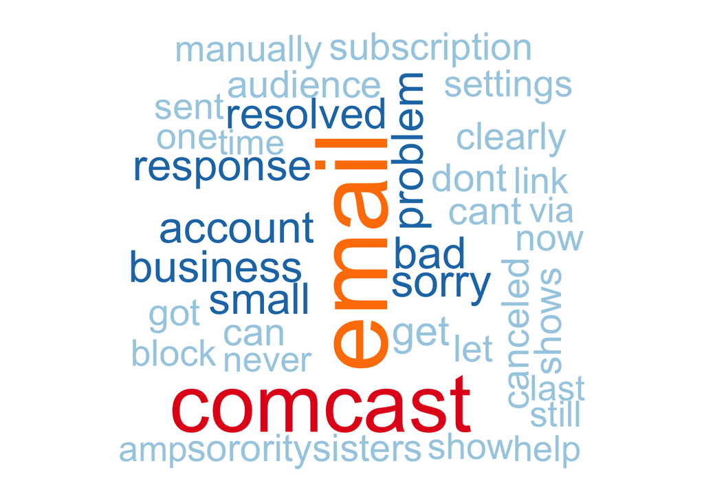

```r
library(wordcloud) ##Lets me do word clouds
library(RColorBrewer) ##Allows for many different color pallets

wordcloud(text, scale=c(6, 2), random.order = FALSE, colors=brewer.pal(8, "Paired"))
```

### Seeing a pie chart of the overall sentiment

Which is also available via my make_piechart.R script.

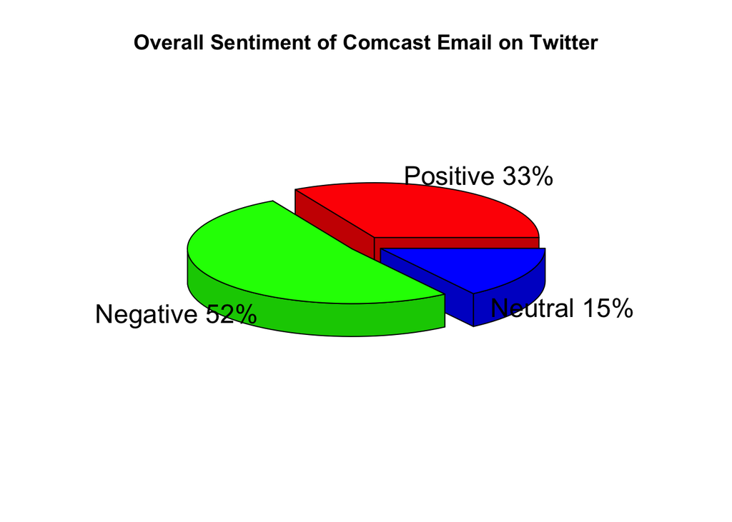

```r
library(plotrix) ##Alows for pie charts

##segment the matrix by sentiment
postweets <- totalFinalOutput[totalFinalOutput$polarity == "positive", ]
neuttweets <- totalFinalOutput[totalFinalOutput$polarity == "neutral", ]
negtweets <- totalFinalOutput[totalFinalOutput$polarity == "negative", ]

##get a value for the number of rows in each matrix
total <- dim(totalFinalOutput)[1]
posnum <- dim(postweets)[1]
negnum <- dim(negtweets)[1]
neutnum <- dim(neuttweets)[1]

##calculate the percentage for each sentiment value
posperc <- posnum/total
negperc <- negnum/total
neutperc <- neutnum/total

##create the pie chart slices, labels, and add the percentage
slices <- c(posnum, negnum, neutnum)
lbls <- c("Positive", "Negative", "Neutral")
pct <- round(slices/sum(slices)*100)
lbls <- paste(lbls, pct)
lbls <- paste(lbls, "%", sep = "")

pie3D(slices, labels=lbls, explode=0.1, main="Overall Sentiment of Comcast Email on Twitter")
```